# Разработка модели регрессии для молочной фермы

Вы работаете в IT-компании, которая выполняет на заказ проекты по машинному обучению. К вам обратился фермер, владелец молочного хозяйства «Вольный луг». Он хочет купить бурёнок, чтобы расширить поголовье стада коров. Для этого он заключил выгодный контракт с ассоциацией пастбищ «ЭкоФерма».

Условия позволяют фермеру очень тщательно отобрать коров. Он определяет качество молока по строгой методике, и при этом ему нужно выполнять свой план развития молочного хозяйства. Фермер хочет, чтобы каждая бурёнка давала не менее 6000 килограммов молока в год, а её надой был вкусным — строго по его критериям, ничуть не хуже. А продавцы и технологи так и норовят приукрасить своих коровок!

Поэтому он просит вас разработать модель машинного обучения, которая поможет ему управлять рисками и принимать объективное решение о покупке. «ЭкоФерма» готова предоставить подробные данные о своих коровах. Вам нужно создать две прогнозные модели для отбора бурёнок в поголовье:

1. Первая будет прогнозировать возможный удой коровы;
2. Вторая — рассчитывать вероятность получить вкусное молоко от коровы.

С помощью модели нужно отобрать коров по двум критериям:

- средний удой за год — не менее 6000 килограммов;
- молоко должно быть вкусным.

# Цель проекта

Разработать инструмент для отбора коров для владельца молочного хозяйства, чтобы помочь ему объективно отбирать коров для расширения стада и минимизировать риски при покупке.

**Задача 1:**

Решение задачи регрессии и обучения с учителем.

Цель: Построить модель, будет прогнозировать годовой удой коровы (не менее 6000 кг).

**Задача 2:**

Решение задачи классификации и обучения с учителем.

Цель: Построить модель, которая будет оценивать вероятность получения вкусного молока по критериям фермера.

# Описание данных

Путь к файлам:

- `/datasets/ferma_main.csv`
- `/datasets/ferma_dad.csv`
- `/datasets/cow_buy.csv`
1. Файл `ferma_main.csv` содержит данные о стаде фермера на текущий момент. Описание данных:
- `'id'` — уникальный идентификатор коровы.
- `'Удой, кг'` — масса молока, которую корова даёт в год (в килограммах).
- `'ЭКЕ (Энергетическая кормовая единица)'` — показатель питательности корма коровы.
- `'Сырой протеин, г'` — содержание сырого протеина в корме (в граммах).
- `'СПО (Сахаро-протеиновое соотношение)'` — отношение сахара к протеину в корме коровы.
- `'Порода'` — порода коровы.
- `'Тип пастбища'` — ландшафт лугов, на которых паслась корова.
- `'порода папы_быка'` — порода папы коровы.
- `'Жирность,%'` — содержание жиров в молоке (в процентах).
- `'Белок,%'` — содержание белков в молоке (в процентах).
- `'Вкус молока'` — оценка вкуса по личным критериям фермера, бинарный признак (`'вкусно'`, `'не вкусно'`).
- `'Возраст'` — возраст коровы, бинарный признак (`'менее_2_лет'`, `'более_2_лет'`).

Признаки в датасете `ferma_main.csv` можно разделить на группы.

- Характеристики коровы: `'id'`, `'Порода'`, `'порода папы_быка'`, `'Возраст'`.
- Характеристики корма: `'ЭКЕ (Энергетическая кормовая единица)'`, `'Сырой протеин, г'`, `'СПО (Сахаро-протеиновое соотношение)'`.
- Характеристика пастбища: `'Тип пастбища'`.
- Характеристики молока: `'Удой, кг'`, `'Жирность,%'`, `'Белок,%'`, `'Вкус молока'`.
1. Файл `ferma_dad.csv` хранит имя папы каждой коровы в стаде фермера. Описание данных:
- `'id'` — уникальный идентификатор коровы.
- `'Имя Папы'` — имя папы коровы.
1. Файл `cow_buy.csv` — это данные о коровах «ЭкоФермы», которых фермер хочет изучить перед покупкой. Описание данных:
- `'Порода'` — порода коровы.
- `'Тип пастбища'` — ландшафт лугов, на которых паслась корова.
- `'порода папы_быка'` — порода папы коровы.
- `'Имя_папы'` — имя папы коровы.
- `'Текущая_жирность,%'` — содержание жиров в молоке (в процентах).
- `'Текущий_уровень_белок,%'` — содержание белков в молоке (в процентах).
- `'Возраст'` — возраст коровы, бинарный признак (`'менее_2_лет'`, `'более_2_лет'`).

Данные в файлах `ferma_main.csv` и `cow_buy.csv` похожи, но у датасета `cow_buy.csv` несколько особенностей.

- Содержание белков и жиров в молоке указано на момент продажи — когда «ЭкоФерма» давала коровам свой корм.
- Параметры корма `'ЭКЕ (Энергетическая кормовая единица)'`, `'Сырой протеин, г'` и `'СПО (Сахаро-протеиновое соотношение)'` отсутствуют. Технологи заказчика пересмотрели подход к кормлению: для новых коров планируется увеличить значения каждого из этих параметров на 5%.
- Кроме того, отсутствуют признаки `'Удой, кг'` и `'Вкус молока'`. Это целевые признаки, которые предстоит предсказать.

# План работы

1. Загрузка и изучение данных.
1. Предобработка данных.
1. Исследовательский анализ данных.
   - Проведение статистического анализа всех признаков.
   - Постройте графиков для каждого признака.
1. Корреляционный анализ признаков.
   - Изучение взаимосвязи между признаками с помощью коэффициентов корреляции.
   - Построение диаграммы рассеяния признака `'Удой'` и всех количественных признаков с учётом значения категориальных признаков.
1. Задача регрессии.
   - Целевой признак - `'Удой'`.
   - Отбор признаков, подходящих для модели линейной регрессии.
   - Разбивка данных на тренировочную и тестовую выборки.
   - Кодирование категориальных признаков с помощью OneHotEncoder.
   - Масштабирование количественных признаков с помощью StandardScaler.
   - Обучение модели на подготовленных данных.
   - Оценка качества модели на тестовой выборке (R², анализ остатков).
   - Повторение предыдущих пунктов для создания новой модели с подбором более подходящих признаков и добавлением новых.
   - Сравние качества получившихся моделей линейной регрессии: сопоставление их R² и остатков, расчет метрик MSE, MAE и RMSE.
   - Прогнозирование с помощью лучшей модели удоя коров, которых фермер хочет купить.
1. Задача классификации.
   - Целевой признак - `'Вкус молока'`.
   - Отбор признаков, подходящих для модели логистической регрессии.
   - Разбивка данных на тренировочную и тестовую выборки.
   - Кодирование категориальных признаков с помощью OneHotEncoder.
   - Масштабирование количественных признаков с помощью StandardScaler.
   - Обучение модели на подготовленных данных.
   - Оценка качества модели на тестовой выборке (accuracy, recall, precision, матрица ошибок).
   - Повторение предыдущих пунктов для создания новой модели с подбором более подходящих признаков и добавлением новых. Сведение критичной ошибки к нулю при помощи изменения порога принадлежности к классам.
   - Прогнозирование с помощью лучшей модели вкуса молока коров, которых фермер хочет купить.

# Содержание

## Загрузка данных

### Импорт и установка библиотек и загрузка данных файла

Импортируем необходимые для работы библиотеки.

```python
!pip install phik -q
```

```python
import pandas as pd
import numpy as np
import seaborn as sns
import matplotlib.pyplot as plt

from IPython.display import HTML
from scipy import stats as st

from sklearn.model_selection import train_test_split

from sklearn.preprocessing import (
    OneHotEncoder,
    StandardScaler
)

from sklearn.linear_model import (
    LinearRegression,
    LogisticRegression
)

from sklearn.metrics import (
    r2_score,
    mean_absolute_error,
    mean_squared_error,
    accuracy_score,
    recall_score,
    precision_score,
    confusion_matrix
)

import phik
```

```python
# Фиксируем переменную RANDOM_STATE для
# одинакового деления выборок при перезапуске.
RANDOM_STATE = 42
```

### Создание функций

Создадим функции, которые нам потребуются в работе.

```python
# Функция для отображения списка только
# категориальных столбцов датафрейма.
def cat_col(data):
    return data.select_dtypes(exclude=[np.number]).columns
```

```python
# Функция для отображения списка только
# количественных столбцов датафрейма.
def int_col(data):
    return data.select_dtypes(include=[np.number]).columns
```

```python
# Функция для предварительного изучения
# общей информации о данных.
def data_research(dataset):

    display(dataset.head())
    display(dataset.tail())
    print()

    display(HTML('<h3>Общая информация о данных</h3><br>'))
    print(dataset.info())

    if dataset.isna().sum().any():

        display(HTML('<br><h3>Количество пропущенных значений</h3><br>'))
        print(dataset.isna().sum())

        display(HTML('<br><h3>Доля пропущенных значений</h3><br>'))
        display(HTML(f'<b>Во всем датафрейме: </b>'\
                     f'{round((dataset.isna().sum().sum() / (dataset.shape[0] * dataset.shape[1]) * 100), 1)}%<br>'))


        display(HTML('<b>В каждом столбце: </b>'))
        display(pd.DataFrame(dataset.isna().mean()*100).style.set_precision(1).background_gradient('coolwarm'))

    else:
        pass

    if len(int_col(dataset)) != 0:

        display(HTML('<br><h3>Описание данных</h3>'))
        display(dataset.describe())

        display(HTML('<br><h3>Гистограммы для всех числовых столбцов таблицы</h3><br>'))
        axes = dataset.hist(figsize=(10, 10), xlabelsize=10, ylabelsize=10)

        # Добавляем подписи осей
        for ax in axes.flatten():
            ax.set_xlabel(ax.get_title(), fontsize=12)
            ax.set_ylabel('Количество коров', fontsize=12)

        plt.tight_layout()
        plt.show()

    else:
        pass
```

```python
# Функция для построения графиков для количественных признаков
def quantitative_plot(data, column, step_size):

    # Округим минимальное значение вниз и максимальное значение вверх
    # до ближайшего числа, кратного шагу для ровного отображения колонок
    min_value = np.floor(data[column].min() / step_size) * step_size
    max_value = np.ceil(data[column].max() / step_size) * step_size + step_size * 1.5

    data.hist(column=column,
              bins=np.arange(min_value, max_value, step_size),
              figsize=(10, 5));

    plt.ylabel('Количество коров')
```

```python
# Функция для построения круговой диаграмы для категориальных признаков
def categorical_plot(data, column):
    data[column].sort_values()\
                .value_counts()\
                .sort_index()\
                .plot(kind='pie',
                      figsize=(8, 8),
                      autopct='%1.1f%%',
                      colors=['lightskyblue', 'orchid', 'orange', 'yellowgreen']);
```

```python
# Функция для оценки качества модели
# на тестовой выборке при помощи R².
def R2(pred):
    return r2_score(y_test, pred)
```

```python
# Функция для анализа остатков с помощью графиков.
def residuals_plot(pred):
    # рассчитаем остатки
    residuals = y_test - pred

    # гистограмма частотности распределения
    fig, axes = plt.subplots(nrows=1, ncols=2, figsize=(10,5))
    axes[0].hist(residuals)
    axes[0].set_title('Гистограмма распределения остатков')
    axes[0].set_xlabel('Остатки')
    axes[0].grid(True)

    # диаграмма рассеяния
    axes[1].scatter(residuals, pred)
    axes[1].set_title('Анализ дисперсии')
    axes[1].set_xlabel('Остатки')
    axes[1].set_ylabel('Предсказания модели')
    axes[1].grid(True)

    plt.show()
```

```python
# Функция для расчёта метрик accuracy, precision и recall.
def apr_metrics(pred):
    print('Accuracy =', accuracy_score(y_test, pred))
    print('Precision =', precision_score(y_test, pred, pos_label='вкусно'))
    print('Recall =', recall_score(y_test, pred, pos_label='вкусно'))
```

```python
# Функция для построения матрицы ошибок.
def cm_plot(true, pred):
    plt.figure(figsize=(8, 6))
    sns.heatmap(confusion_matrix(true, pred), annot=True, fmt='d', cmap='Blues_r',
                xticklabels=['невкусно', 'вкусно'], yticklabels=['невкусно', 'вкусно'])
    plt.xlabel('Предсказанные метки')
    plt.ylabel('Истинные метки')
    plt.title('Матрица ошибок')
    plt.show()
```

### Загрузка данных файла

Загружаем данные из csv-файла в датафрейм.

```python
main_data = pd.read_csv('/datasets/ferma_main.csv', sep=';', decimal = ',')
dad_data = pd.read_csv('/datasets/ferma_dad.csv', sep=';', decimal = ',')
buy_data = pd.read_csv('/datasets/cow_buy.csv', sep=';', decimal = ',')
```

Сохраним все датафреймы в одной переменной для удобства обращенияя к ним в повторяющихся операциях.

```python
all_data = ['main_data', 'dad_data', 'buy_data']
```

### Изучение общей информации о датафрейме

Изучим информацию при помощи функции `data_research`.

Датафрейм main_data

|  | id | Удой, кг | ЭКЕ (Энергетическая кормовая единица) | Сырой протеин, г | СПО (Сахаро-протеиновое соотношение) | Порода | Тип пастбища | порода папы_быка | Жирность,% | Белок,% | Вкус молока | Возраст |
| --- | --- | --- | --- | --- | --- | --- | --- | --- | --- | --- | --- | --- |
| 0 | 1 | 5863 | 14.2 | 1743 | 0.890 | Вис Бик Айдиал | Равнинное | Айдиал | 3.58 | 3.076 | вкусно | более_2_лет |
| 1 | 2 | 5529 | 12.8 | 2138 | 0.890 | Вис Бик Айдиал | Равнинные | Соверин | 3.54 | 3.079 | вкусно | менее_2_лет |
| 2 | 3 | 5810 | 14.0 | 1854 | 0.885 | РефлешнСоверинг | Холмистое | Соверин | 3.59 | 3.074 | не вкусно | более_2_лет |
| 3 | 4 | 5895 | 12.4 | 2012 | 0.885 | РефлешнСоверинг | Холмистое | Айдиал | 3.40 | 3.075 | не вкусно | более_2_лет |
| 4 | 5 | 5302 | 12.8 | 1675 | 0.885 | Вис Бик Айдиал | Равнинные | Соверин | 3.73 | 3.073 | вкусно | менее_2_лет |

|  | id | Удой, кг | ЭКЕ (Энергетическая кормовая единица) | Сырой протеин, г | СПО (Сахаро-протеиновое соотношение) | Порода | Тип пастбища | порода папы_быка | Жирность,% | Белок,% | Вкус молока | Возраст |
| --- | --- | --- | --- | --- | --- | --- | --- | --- | --- | --- | --- | --- |
| 629 | 627 | 5970 | 14.4 | 1837 | 0.88 | РефлешнСоверинг | Холмистое | Соверин | 3.64 | 3.075 | не вкусно | более_2_лет |
| 630 | 627 | 5970 | 14.4 | 1837 | 0.88 | РефлешнСоверинг | Холмистое | Соверин | 3.64 | 3.075 | не вкусно | более_2_лет |
| 631 | 627 | 5970 | 14.4 | 1837 | 0.88 | РефлешнСоверинг | Холмистое | Соверин | 3.64 | 3.075 | не вкусно | более_2_лет |
| 632 | 627 | 5970 | 14.4 | 1837 | 0.88 | РефлешнСоверинг | Холмистое | Соверин | 3.64 | 3.075 | не вкусно | более_2_лет |
| 633 | 627 | 5970 | 14.4 | 1837 | 0.88 | РефлешнСоверинг | Холмистое | Соверин | 3.64 | 3.075 | не вкусно | более_2_лет |

Общая информация о данных

```
<class 'pandas.core.frame.DataFrame'>
RangeIndex: 634 entries, 0 to 633
Data columns (total 12 columns):
 #   Column                                 Non-Null Count  Dtype
---  ------                                 --------------  -----
 0   id                                     634 non-null    int64
 1   Удой, кг                               634 non-null    int64
 2   ЭКЕ (Энергетическая кормовая единица)  634 non-null    float64
 3   Сырой протеин, г                       634 non-null    int64
 4   СПО (Сахаро-протеиновое соотношение)   634 non-null    float64
 5   Порода                                 634 non-null    object
 6   Тип пастбища                           634 non-null    object
 7   порода папы_быка                       634 non-null    object
 8   Жирность,%                             634 non-null    float64
 9   Белок,%                                634 non-null    float64
 10  Вкус молока                            634 non-null    object
 11  Возраст                                634 non-null    object
dtypes: float64(4), int64(3), object(5)
memory usage: 59.6+ KB
None
```

Описание данных

|  | id | Удой, кг | ЭКЕ (Энергетическая кормовая единица) | Сырой протеин, г | СПО (Сахаро-протеиновое соотношение) | Жирность,% | Белок,% |
| --- | --- | --- | --- | --- | --- | --- | --- |
| count | 634.000000 | 634.000000 | 634.000000 | 634.000000 | 634.000000 | 634.000000 | 634.000000 |
| mean | 317.460568 | 6187.025237 | 14.542744 | 1922.682965 | 0.912855 | 3.603943 | 3.075666 |
| std | 183.096982 | 1638.401021 | 1.301301 | 182.392548 | 0.032209 | 0.168020 | 0.002540 |
| min | 1.000000 | 5204.000000 | 10.900000 | 1660.000000 | 0.840000 | 2.990000 | 3.069000 |
| 25% | 159.250000 | 5751.750000 | 13.500000 | 1772.250000 | 0.890000 | 3.590000 | 3.074000 |
| 50% | 317.500000 | 6130.500000 | 14.700000 | 1880.500000 | 0.930000 | 3.650000 | 3.076000 |
| 75% | 475.750000 | 6501.000000 | 15.600000 | 2058.750000 | 0.940000 | 3.720000 | 3.077000 |
| max | 629.000000 | 45616.000000 | 16.800000 | 2349.000000 | 0.960000 | 3.750000 | 3.085000 |

Гистограммы для всех числовых столбцов таблицы

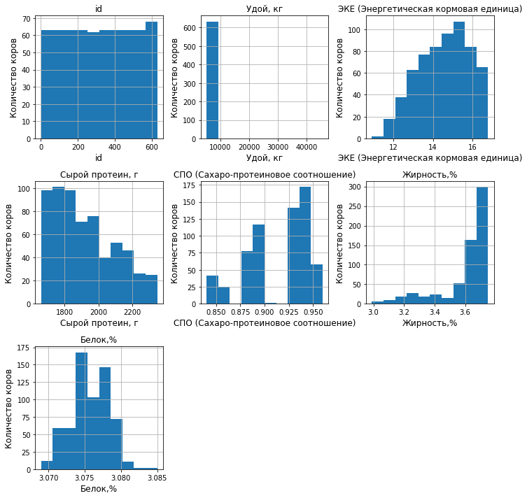

Датафрейм dad_data

|  | id | Имя Папы |
| --- | --- | --- |
| 0 | 1 | Буйный |
| 1 | 2 | Соловчик |
| 2 | 3 | Барин |
| 3 | 4 | Буйный |
| 4 | 5 | Барин |

|  | id | Имя Папы |
| --- | --- | --- |
| 624 | 625 | Буйный |
| 625 | 626 | Барин |
| 626 | 627 | Барин |
| 627 | 628 | Барин |
| 628 | 629 | Соловчик |

Общая информация о данных

```
<class 'pandas.core.frame.DataFrame'>
RangeIndex: 629 entries, 0 to 628
Data columns (total 2 columns):
 #   Column    Non-Null Count  Dtype
---  ------    --------------  -----
 0   id        629 non-null    int64
 1   Имя Папы  629 non-null    object
dtypes: int64(1), object(1)
memory usage: 10.0+ KB
None
```

Описание данных

|  | id |
| --- | --- |
| count | 629.00000 |
| mean | 315.00000 |
| std | 181.72094 |
| min | 1.00000 |
| 25% | 158.00000 |
| 50% | 315.00000 |
| 75% | 472.00000 |
| max | 629.00000 |

Гистограммы для всех числовых столбцов таблицы

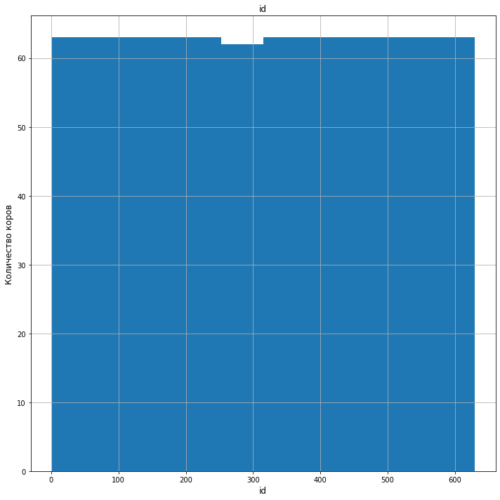

Датафрейм buy_data

|  | Порода | Тип пастбища | порода папы_быка | Имя_папы | Текущая_жирность,% | Текущий_уровень_белок,% | Возраст |
| --- | --- | --- | --- | --- | --- | --- | --- |
| 0 | Вис Бик Айдиал | холмистое | Айдиал | Геркулес | 3.58 | 3.076 | более_2_лет |
| 1 | Вис Бик Айдиал | равнинное | Соверин | Буйный | 3.54 | 3.081 | менее_2_лет |
| 2 | РефлешнСоверинг | равнинное | Соверин | Барин | 3.59 | 3.074 | более_2_лет |
| 3 | РефлешнСоверинг | холмистое | Айдиал | Буйный | 3.40 | 3.061 | более_2_лет |
| 4 | РефлешнСоверинг | равнинное | Айдиал | Буйный | 3.64 | 3.074 | более_2_лет |

|  | Порода | Тип пастбища | порода папы_быка | Имя_папы | Текущая_жирность,% | Текущий_уровень_белок,% | Возраст |
| --- | --- | --- | --- | --- | --- | --- | --- |
| 15 | РефлешнСоверинг | холмистое | Айдиал | Буйный | 3.40 | 3.065 | более_2_лет |
| 16 | Вис Бик Айдиал | холмистое | Соверин | Соловчик | 3.73 | 3.079 | более_2_лет |
| 17 | РефлешнСоверинг | равнинное | Соверин | Геркулес | 3.77 | 3.053 | менее_2_лет |
| 18 | Вис Бик Айдиал | равнинное | Соверин | Буйный | 3.34 | 3.069 | более_2_лет |
| 19 | РефлешнСоверинг | равнинное | Айдиал | Буйный | 3.64 | 3.074 | более_2_лет |

Общая информация о данных

```
<class 'pandas.core.frame.DataFrame'>
RangeIndex: 20 entries, 0 to 19
Data columns (total 7 columns):
 #   Column                   Non-Null Count  Dtype
---  ------                   --------------  -----
 0   Порода                   20 non-null     object
 1   Тип пастбища             20 non-null     object
 2   порода папы_быка         20 non-null     object
 3   Имя_папы                 20 non-null     object
 4   Текущая_жирность,%       20 non-null     float64
 5   Текущий_уровень_белок,%  20 non-null     float64
 6   Возраст                  20 non-null     object
dtypes: float64(2), object(5)
memory usage: 1.2+ KB
None
```

Описание данных

|  | Текущая_жирность,% | Текущий_уровень_белок,% |
| --- | --- | --- |
| count | 20.000000 | 20.000000 |
| mean | 3.577500 | 3.069500 |
| std | 0.126818 | 0.010339 |
| min | 3.340000 | 3.046000 |
| 25% | 3.510000 | 3.064000 |
| 50% | 3.590000 | 3.074000 |
| 75% | 3.650000 | 3.076000 |
| max | 3.770000 | 3.081000 |

Гистограммы для всех числовых столбцов таблицы

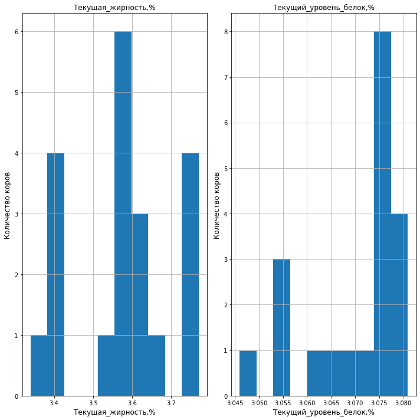

```python
for data_name in all_data:
    data = eval(data_name)
    display(HTML(f'<br><br><h1>Датафрейм {data_name}</h1>'))
    data_research(data)
```

### Вывод

Данные загружены, они соответствуют описанию задачи. Судя по полученным данным, в таблицах нет пропущенных значений, которые бы требовалось обработать. Но обнаружены следующие несоответствия:

- В таблицах наименования столбцов и данные-строки не соответствуют стандартам оформления данных. Неокторые наименования очень габаритны, записи имеют разные формы, и даже язык. Необходимо исправить наименования столбцов и данных-строк, приведя их к одному языку и змеиному регистру, и сделать их более лаконичными.
- В столбце `'Удой'` датафрейма `main_data` видны аномально большие значения, похожие на выбросы. Их необходимо изучить подробнее.

Вернуться к содержанию

## Предобработка данных

### Изменение наименования столбцов

Необходимо оформить наименования столбцов в соответствии со стандартами оформления данных. Изучим подробнее наименования всех столбцов.

```python
for data_name in all_data:
    data = eval(data_name)
    display(HTML(f'<b>Столбцы датафрейма {data_name}</b>'))
    print(f'{data.columns.tolist()}\n')
```

**Столбцы датафрейма main_data**

```
['id', 'Удой, кг', 'ЭКЕ (Энергетическая кормовая единица)', 'Сырой протеин, г', 'СПО (Сахаро-протеиновое соотношение)', 'Порода', 'Тип пастбища', 'порода папы_быка', 'Жирность,%', 'Белок,%', 'Вкус молока', 'Возраст']
```

**Столбцы датафрейма dad_data**

```
['id', 'Имя Папы']
```

**Столбцы датафрейма buy_data**

```
['Порода', 'Тип пастбища', 'порода папы_быка', 'Имя_папы', 'Текущая_жирность,%', 'Текущий_уровень_белок,%', 'Возраст']
```

Оставим все наименования столбцов на русском языке, приведем их к змеиному регистру. Также уберем пояснения в скобках и упоминания единиц измерения.

```python
main_data = main_data.rename(columns={
    'id': 'ид',
    'Удой, кг': 'удой',
    'ЭКЕ (Энергетическая кормовая единица)': 'эке',
    'Сырой протеин, г': 'сырой_протеин',
    'СПО (Сахаро-протеиновое соотношение)': 'спо',
    'Порода': 'порода',
    'Тип пастбища': 'тип_пастбища',
    'порода папы_быка': 'порода_папы',
    'Жирность,%': 'жирность',
    'Белок,%': 'белок',
    'Вкус молока': 'вкус_молока',
    'Возраст': 'возраст'
})
```

```python
dad_data = dad_data.rename(columns={
    'id': 'ид',
    'Имя Папы': 'имя_папы'
})
```

```python
buy_data = buy_data.rename(columns={
    'Порода': 'порода',
    'Тип пастбища': 'тип_пастбища',
    'порода папы_быка': 'порода_папы',
    'Имя_папы': 'имя_папы',
    'Текущая_жирность,%': 'жирность',
    'Текущий_уровень_белок,%': 'белок',
    'Возраст': 'возраст'
})
```

Проверяем результат.

```python
for data_name in all_data:
    data = eval(data_name)
    display(HTML(f'<b>Столбцы датафрейма {data_name}</b>'))
    print(f'{data.columns.tolist()}\n')
```

**Столбцы датафрейма main_data**

```
['ид', 'удой', 'эке', 'сырой_протеин', 'спо', 'порода', 'тип_пастбища', 'порода_папы', 'жирность', 'белок', 'вкус_молока', 'возраст']
```

**Столбцы датафрейма dad_data**

```
['ид', 'имя_папы']
```

**Столбцы датафрейма buy_data**

```
['порода', 'тип_пастбища', 'порода_папы', 'имя_папы', 'жирность', 'белок', 'возраст']
```

Теперь наименования столбцов выглядят корректно.

### Устранение дубликатов

Проверим количество строк у каждого датафрейма.

```python
for data_name in all_data:
    data = eval(data_name)
    print(f'Длина датафрейма {data_name}: {data.shape[0]}')
```

```
Длина датафрейма main_data: 634
Длина датафрейма dad_data: 629
Длина датафрейма buy_data: 20
```

#### Явные дубликаты

Сперва проверим, нет ли в таблице явных дубликатов.

```python
for data_name in all_data:
    data = eval(data_name)
    print(f'Количество дубликатов в датафрейме {data_name}: {data.duplicated().sum()} '
          f'({(data.duplicated().sum() / data.shape[0]):.2%} от общего размера)\n')
```

```
Количество дубликатов в датафрейме main_data: 5 (0.79% от общего размера)

Количество дубликатов в датафрейме dad_data: 0 (0.00% от общего размера)

Количество дубликатов в датафрейме buy_data: 4 (20.00% от общего размера)
```

В датафрейме `main_data` и `buy_data` обнаружены 5 и 4 дубликатов соответственно. Взглянем на них.

```python
main_data[main_data.duplicated()]
```

|  | ид | удой | эке | сырой_протеин | спо | порода | тип_пастбища | порода_папы | жирность | белок | вкус_молока | возраст |
| --- | --- | --- | --- | --- | --- | --- | --- | --- | --- | --- | --- | --- |
| 629 | 627 | 5970 | 14.4 | 1837 | 0.88 | РефлешнСоверинг | Холмистое | Соверин | 3.64 | 3.075 | не вкусно | более_2_лет |
| 630 | 627 | 5970 | 14.4 | 1837 | 0.88 | РефлешнСоверинг | Холмистое | Соверин | 3.64 | 3.075 | не вкусно | более_2_лет |
| 631 | 627 | 5970 | 14.4 | 1837 | 0.88 | РефлешнСоверинг | Холмистое | Соверин | 3.64 | 3.075 | не вкусно | более_2_лет |
| 632 | 627 | 5970 | 14.4 | 1837 | 0.88 | РефлешнСоверинг | Холмистое | Соверин | 3.64 | 3.075 | не вкусно | более_2_лет |
| 633 | 627 | 5970 | 14.4 | 1837 | 0.88 | РефлешнСоверинг | Холмистое | Соверин | 3.64 | 3.075 | не вкусно | более_2_лет |

```python
buy_data[buy_data.duplicated()]
```

|  | порода | тип_пастбища | порода_папы | имя_папы | жирность | белок | возраст |
| --- | --- | --- | --- | --- | --- | --- | --- |
| 6 | Вис Бик Айдиал | холмистое | Айдиал | Геркулес | 3.58 | 3.076 | более_2_лет |
| 8 | РефлешнСоверинг | равнинное | Соверин | Барин | 3.59 | 3.074 | более_2_лет |
| 14 | РефлешнСоверинг | равнинное | Соверин | Барин | 3.59 | 3.074 | более_2_лет |
| 19 | РефлешнСоверинг | равнинное | Айдиал | Буйный | 3.64 | 3.074 | более_2_лет |

Данные выглядят нормально. Видно, что в датафрейме `main_data` все 5 дублей повторяют одну строку.

В датафрейме `buy_data` есть вероятность, что это не дубликаты, а разные коровы с одинаковыми параметрами. Этот датафрейм не будет участвовать в обучении моделей, поэтому дубли в нём некритичны, лучше их оставить.

Удалим явные дубликаты только в `main_data` и обновим индексы.

```python
main_data = main_data.drop_duplicates().reset_index(drop=True)
```

Проверяем результат.

```python
print('Количество дубликатов в датафрейме', main_data.duplicated().sum())
main_data.tail()
```

```
Количество дубликатов в датафрейме 0
```

|  | ид | удой | эке | сырой_протеин | спо | порода | тип_пастбища | порода_папы | жирность | белок | вкус_молока | возраст |
| --- | --- | --- | --- | --- | --- | --- | --- | --- | --- | --- | --- | --- |
| 624 | 625 | 6812 | 15.4 | 1964 | 0.94 | РефлешнСоверинг | Равнинное | Айдиал | 3.74 | 3.075 | не вкусно | более_2_лет |
| 625 | 626 | 5513 | 12.9 | 1700 | 0.88 | РефлешнСоверинг | Равнинное | Соверин | 3.64 | 3.073 | вкусно | менее_2_лет |
| 626 | 627 | 5970 | 14.4 | 1837 | 0.88 | РефлешнСоверинг | Холмистое | Соверин | 3.64 | 3.075 | не вкусно | более_2_лет |
| 627 | 628 | 5746 | 13.8 | 1994 | 0.89 | РефлешнСоверинг | Равнинное | Соверин | 3.64 | 3.077 | вкусно | более_2_лет |
| 628 | 629 | 6503 | 16.2 | 2283 | 0.94 | Вис Бик Айдиал | Холмистое | Соверин | 3.71 | 3.076 | вкусно | более_2_лет |

Мы избавились от 5 явных дубликатов, индексы отображаются корректно.

#### Неявные дубликаты

Изучим во всех датафреймах уникальные значения в каждом столбце, который имеет нечисловой тип данных. Также посмотрим, как часто упоминается каждое из уникальных значений.

```python
for data_name in all_data:
    data = eval(data_name)
    display(HTML(f'<br><h3>Датафрейм {data_name}</h3>'))
    for column in cat_col(data):
        display(HTML(f'<b>Уникальные значения в столбце "{column}": </b>{len(data[column].unique())}'))
        print(data[column].value_counts().to_string(header=False))
```

Датафрейм main_data

**Уникальные значения в столбце "порода":** 2

```
Вис Бик Айдиал     373
РефлешнСоверинг    256
```

**Уникальные значения в столбце "тип_пастбища":** 3

```
Холмистое    351
Равнинное    253
Равнинные     25
```

**Уникальные значения в столбце "порода_папы":** 3

```
Соверин    311
Айдиал     240
Айдиалл     78
```

**Уникальные значения в столбце "вкус_молока":** 2

```
вкусно       371
не вкусно    258
```

**Уникальные значения в столбце "возраст":** 2

```
более_2_лет    519
менее_2_лет    110
```

Датафрейм dad_data

**Уникальные значения в столбце "имя_папы":** 4

```
Барин       240
Буйный      215
Соловчик    110
Геркулес     64
```

Датафрейм buy_data

**Уникальные значения в столбце "порода":** 2

```
РефлешнСоверинг    11
Вис Бик Айдиал      9
```

**Уникальные значения в столбце "тип_пастбища":** 2

```
равнинное    11
холмистое     9
```

**Уникальные значения в столбце "порода_папы":** 2

```
Соверин    12
Айдиал      8
```

**Уникальные значения в столбце "имя_папы":** 4

```
Буйный      8
Геркулес    6
Барин       4
Соловчик    2
```

**Уникальные значения в столбце "возраст":** 2

```
более_2_лет    15
менее_2_лет     5
```

Неявные дубликаты присутствуют только в датафрейме `main_data` в столбцах `'тип_пастбища'` и `'порода_папы'`.

Взглянем на данные со значением `'Равнинные'` в столбце `'тип_пастбища'` и значением `'Айдиалл'` в столбце `'порода_папы'`.

```python
main_data[main_data['тип_пастбища'] == 'Равнинные'].head()
```

|  | ид | удой | эке | сырой_протеин | спо | порода | тип_пастбища | порода_папы | жирность | белок | вкус_молока | возраст |
| --- | --- | --- | --- | --- | --- | --- | --- | --- | --- | --- | --- | --- |
| 1 | 2 | 5529 | 12.8 | 2138 | 0.890 | Вис Бик Айдиал | Равнинные | Соверин | 3.54 | 3.079 | вкусно | менее_2_лет |
| 4 | 5 | 5302 | 12.8 | 1675 | 0.885 | Вис Бик Айдиал | Равнинные | Соверин | 3.73 | 3.073 | вкусно | менее_2_лет |
| 6 | 7 | 5910 | 13.2 | 1792 | 0.885 | Вис Бик Айдиал | Равнинные | Соверин | 3.48 | 3.077 | вкусно | более_2_лет |
| 7 | 8 | 6179 | 14.7 | 1806 | 0.930 | Вис Бик Айдиал | Равнинные | Айдиал | 3.55 | 3.076 | вкусно | более_2_лет |
| 13 | 14 | 6131 | 14.5 | 1766 | 0.930 | РефлешнСоверинг | Равнинные | Айдиал | 3.61 | 3.076 | не вкусно | более_2_лет |

```python
main_data[main_data['порода_папы'] == 'Айдиалл'].head()
```

|  | ид | удой | эке | сырой_протеин | спо | порода | тип_пастбища | порода_папы | жирность | белок | вкус_молока | возраст |
| --- | --- | --- | --- | --- | --- | --- | --- | --- | --- | --- | --- | --- |
| 15 | 16 | 6518 | 15.6 | 1747 | 0.930 | Вис Бик Айдиал | Равнинные | Айдиалл | 3.73 | 3.076 | вкусно | более_2_лет |
| 16 | 17 | 45616 | 11.5 | 1675 | 0.930 | Вис Бик Айдиал | Холмистое | Айдиалл | 3.22 | 3.076 | вкусно | более_2_лет |
| 17 | 18 | 5777 | 12.4 | 1873 | 0.895 | Вис Бик Айдиал | Холмистое | Айдиалл | 3.03 | 3.080 | вкусно | более_2_лет |
| 20 | 21 | 6752 | 15.5 | 1924 | 0.930 | РефлешнСоверинг | Холмистое | Айдиалл | 3.73 | 3.078 | вкусно | более_2_лет |
| 21 | 22 | 6278 | 14.6 | 1947 | 0.930 | РефлешнСоверинг | Холмистое | Айдиалл | 3.49 | 3.071 | вкусно | более_2_лет |

Данные выглядят нормально, поэтому просто заменим некорректные значения на `'Равнинное'` и `'Айдиал'`.

```python
main_data.loc[main_data['тип_пастбища'] == 'Равнинные', 'тип_пастбища'] = 'Равнинное'
```

```python
main_data.loc[main_data['порода_папы'] == 'Айдиалл', 'порода_папы'] = 'Айдиал'
```

Проверяем результат.

```python
print(main_data['тип_пастбища'].value_counts().to_string(header=False))
```

```
Холмистое    351
Равнинное    278
```

```python
print(main_data['порода_папы'].value_counts().to_string(header=False))
```

```
Айдиал     318
Соверин    311
```

Мы обнаружили и обработали 2 неявных дубликата среди уникальных значений столбцов датафреймов, теперь дубликатов нет.

### Оформление нечисловых данных

Оформим нечисловые данные в соответствии со стандартами оформления данных. Изучив уникальные значения столбцов на предыдущем этапе, можно увидеть, что в датафрейме `main_data` и `buy_data` в столбцах `'порода'` и`'возраст'` некорректно оформлены значения. Также у обоих датафреймов отличается столбец `'тип_пастбища'`, имея разные регистры. В датафрейме `main_data` в столбце `'вкус_молока'` напишем `'не вкусно'` слитно.

```python
for data_name in [all_data[i] for i in [0, 2]]:
    data = eval(data_name)
    display(HTML(f'<br><h3>Датафрейм {data_name}</h3>'))
    for column in ['тип_пастбища', 'порода', 'возраст']:
        display(HTML(f'<br><b>Уникальные значения в столбце "{column}":</b>'))
        print(data[column].unique())
```

Датафрейм main_data

**Уникальные значения в столбце "тип_пастбища":**

```
['Равнинное' 'Холмистое']
```

**Уникальные значения в столбце "порода":**

```
['Вис Бик Айдиал' 'РефлешнСоверинг']
```

**Уникальные значения в столбце "возраст":**

```
['более_2_лет' 'менее_2_лет']
```

Датафрейм buy_data

**Уникальные значения в столбце "тип_пастбища":**

```
['холмистое' 'равнинное']
```

**Уникальные значения в столбце "порода":**

```
['Вис Бик Айдиал' 'РефлешнСоверинг']
```

**Уникальные значения в столбце "возраст":**

```
['более_2_лет' 'менее_2_лет']
```

```python
display(HTML(f'<br><b>Уникальные значения в столбце "вкус_молока":</b>'))
print(main_data['вкус_молока'].unique())
```

**Уникальные значения в столбце "вкус_молока":**

```
['вкусно' 'не вкусно']
```

Исправим оформление значений и приведем его к единообразию.

```python
for data in [all_data[i] for i in [0, 2]]:
    data = eval(data)
    data.loc[data['порода'] == 'РефлешнСоверинг', 'порода'] = 'Рефлешн Соверинг'
```

```python
for data in [all_data[i] for i in [0, 2]]:
    data = eval(data)
    data['возраст'] = data['возраст'].str.replace('_', ' ')
```

```python
main_data['тип_пастбища'] = main_data['тип_пастбища'].str.lower()
```

```python
main_data['вкус_молока'] = main_data['вкус_молока'].str.replace(' ', '')
```

Проверяем результат.

```python
for data_name in [all_data[i] for i in [0, 2]]:
    data = eval(data_name)
    display(HTML(f'<br><h3>Датафрейм {data_name}</h3>'))
    for column in ['тип_пастбища', 'порода', 'возраст']:
        display(HTML(f'<br><b>Уникальные значения в столбце "{column}":</b>'))
        print(data[column].unique())
```

Датафрейм main_data

**Уникальные значения в столбце "тип_пастбища":**

```
['равнинное' 'холмистое']
```

**Уникальные значения в столбце "порода":**

```
['Вис Бик Айдиал' 'Рефлешн Соверинг']
```

**Уникальные значения в столбце "возраст":**

```
['более 2 лет' 'менее 2 лет']
```

Датафрейм buy_data

**Уникальные значения в столбце "тип_пастбища":**

```
['холмистое' 'равнинное']
```

**Уникальные значения в столбце "порода":**

```
['Вис Бик Айдиал' 'Рефлешн Соверинг']
```

**Уникальные значения в столбце "возраст":**

```
['более 2 лет' 'менее 2 лет']
```

```python
display(HTML(f'<br><b>Уникальные значения в столбце "вкус_молока":</b>'))
print(main_data['вкус_молока'].unique())
```

**Уникальные значения в столбце "вкус_молока":**

```
['вкусно' 'невкусно']
```

Теперь нечисловые данные соответствуют стандартам оформления данных и приведены к единообразию.

### Вывод

```python
for data_name in all_data:
    data = eval(data_name)
    print(f'Длина датафрейма "{data_name}": {data.shape[0]}')
```

```
Длина датафрейма "main_data": 629
Длина датафрейма "dad_data": 629
Длина датафрейма "buy_data": 20
```

Наименования всех столбцов были приведены к змеиному регистру, нечисловые данные оформлены в соответствии со стандартами оформления данных.

Вернуться к содержанию

## Исследовательский анализ данных

Для дальнейшего построения графиков для проведения исследовательского анализа будем использовать функции `quantitative_plot` и `categorical_plot`.

### Столбец `'удой'`

Изучим данные по массе молока, которую коровы дают в год.

```python
main_data['удой'].describe();
```

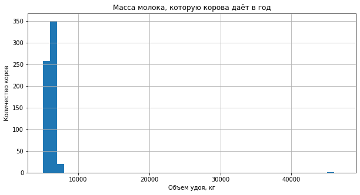

```python
quantitative_plot(main_data, 'удой', 1000)
plt.title('Масса молока, которую корова даёт в год')
plt.xlabel('Объем удоя, кг')
plt.show()
```

На графике все значения собрались в самом начале в три столбца, и виден выброс, равный 45616 кг. Изучим его подробнее.

```python
print('Количество аномальных значений в столбце:',
      len(main_data[main_data['удой'] > 10000]))
main_data[main_data['удой'] > 10000]
```

```
Количество аномальных значений в столбце: 1
```

|  | ид | удой | эке | сырой_протеин | спо | порода | тип_пастбища | порода_папы | жирность | белок | вкус_молока | возраст |
| --- | --- | --- | --- | --- | --- | --- | --- | --- | --- | --- | --- | --- |
| 16 | 17 | 45616 | 11.5 | 1675 | 0.93 | Вис Бик Айдиал | холмистое | Айдиал | 3.22 | 3.076 | вкусно | более 2 лет |

Узнать корректное значение и восстановить его из других столбцов нет возможности, поэтому удалим его из датафрейма.

```python
main_data = main_data[main_data['удой'] < 10000]
```

Проверяем результат.

```python
print('Количество аномальных значений в столбце:',
      len(main_data[main_data['удой'] > 10000]))
```

```
Количество аномальных значений в столбце: 0
```

После избавления от выбросов изучим еще раз данные по столбцу.

```python
main_data['удой'].describe()
```

```
count     628.000000
mean     6125.968153
std       475.857053
min      5204.000000
25%      5749.750000
50%      6132.500000
75%      6501.000000
max      7222.000000
Name: удой, dtype: float64
```

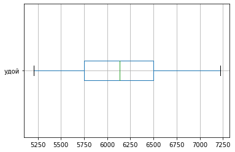

```python
main_data.boxplot(column='удой', vert=False);
```

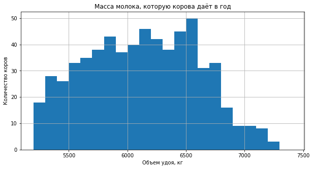

```python
quantitative_plot(main_data, 'удой', 100)
plt.title('Масса молока, которую корова даёт в год')
plt.xlabel('Объем удоя, кг')
plt.show()
```

График очень широкий, разброс объема удоя довольно большой - от 5204 до 7222 кг в год. Значения распределены нормально, но в конце заметен небольшой хвост из значений свыше 6800 кг, которые встречаются реже. На диаграмме размаха выбросы отсутствуют.

Самые часто встречающиеся значения приходятся на промежуток 5800-6600 кг. В среднем каждая корова даёт 6126 кг молока в год.

### Столбец `'эке'`

Изучим данные по показателю питательности корма коровы.

```python
main_data['эке'].describe()
```

```
count    628.000000
mean      14.548726
std        1.301777
min       10.900000
25%       13.500000
50%       14.700000
75%       15.600000
max       16.800000
Name: эке, dtype: float64
```

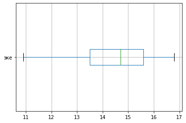

```python
main_data.boxplot(column='эке', vert=False);
```

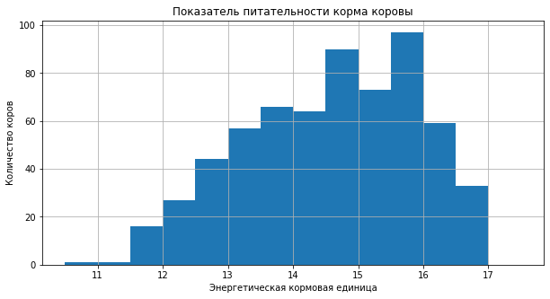

```python
quantitative_plot(main_data, 'эке', 0.5)
plt.title('Показатель питательности корма коровы')
plt.xlabel('Энергетическая кормовая единица')
plt.show()
```

Значения распределены нормально, но пик графика смещен вправо, в начале графика заметен небольшой хвост из малых значений ниже 11.5, которые встречаются редко. На диаграмме размаха выбросы отсутствуют.

Разброс показателя питательности корма коровы - от 10.9 до 16.8.

Самые часто встречающиеся значения приходятся на промежуток 14.5-16. В среднем энергетическая кормовая единица каждой коровы составляет 14.5.

### Столбец `'сырой_протеин'`

Изучим данные по содержанию сырого протеина в корме коровы.

```python
main_data['сырой_протеин'].describe()
```

```
count     628.000000
mean     1923.759554
std       182.832816
min      1660.000000
25%      1771.750000
50%      1888.000000
75%      2062.250000
max      2349.000000
Name: сырой_протеин, dtype: float64
```

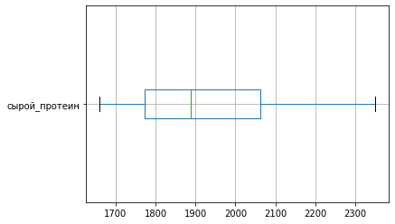

```python
main_data.boxplot(column='сырой_протеин', vert=False);
```

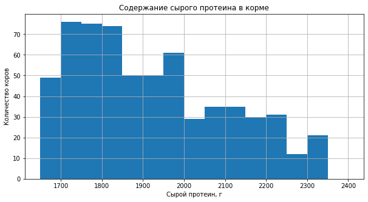

```python
quantitative_plot(main_data, 'сырой_протеин', 50)
plt.title('Cодержание сырого протеина в корме')
plt.xlabel('Сырой протеин, г')
plt.show()
```

График очень широкий, разброс содержания сырого протеина в корме - от 1660 до 2349 г. Пик графика смещен влево, значения свыше 2000 г встречаются реже. На диаграмме размаха выбросы отсутствуют.

Самые часто встречающиеся значения приходятся на промежуток 1700-1850 г. В среднем каждая корова получает 1923 г сырого протеина.

### Столбец `'спо'`

Изучим данные по отношению сахара к протеину в корме коровы.

```python
main_data['спо'].describe()
```

```
count    628.000000
mean       0.913089
std        0.032221
min        0.840000
25%        0.890000
50%        0.930000
75%        0.940000
max        0.960000
Name: спо, dtype: float64
```

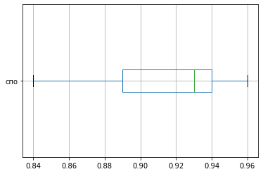

```python
main_data.boxplot(column='спо', vert=False);
```

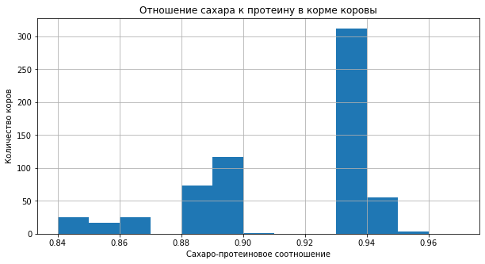

```python
quantitative_plot(main_data, 'спо', 0.01)
plt.title('Отношение сахара к протеину в корме коровы')
plt.xlabel('Сахаро-протеиновое соотношение')
plt.show()
```

Значения распределены необычно, график разбился на три группы: 0.84-0.87, 0.88-0.91 и 0.93-0.96. Пик графика смещен вправо, значения из первой и второй группы встречаются гораздо реже. На диаграмме размаха выбросы отсутствуют.

Самые часто встречающиеся значения приходятся на промежуток 0.93-0.94. В среднем отношение сахара к протеину в корме коровы составляет 0.91.

### Столбец `'вкус_молока'`

Изучим данные по оценке вкуса молока коров по личным критериям фермера.

```
Количество значений:
вкусно      370
невкусно    258
```

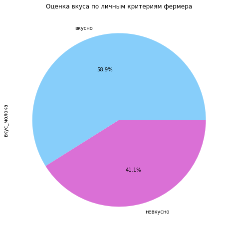

```python
print('Количество значений:')
print(main_data['вкус_молока'].value_counts().to_string(header=False))
categorical_plot(main_data, 'вкус_молока')
plt.title('Оценка вкуса по личным критериям фермера')
plt.show()
```

58.9% коров фермера по его субъективной оценке имеют вкусное молоко, у 41.1% коров молоко невкусное, что на 17.8% меньше первых.

### Столбец `'жирность'`

Изучим данные по содержанию жиров в молоке коров фермера «Вольный луг».

```python
main_data['жирность'].describe()
```

```
count    628.000000
mean       3.604268
std        0.168093
min        2.990000
25%        3.590000
50%        3.650000
75%        3.720000
max        3.750000
Name: жирность, dtype: float64
```

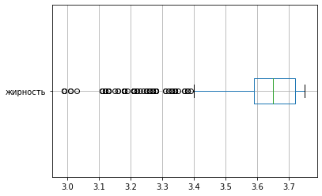

```python
main_data.boxplot(column='жирность', vert=False);
```

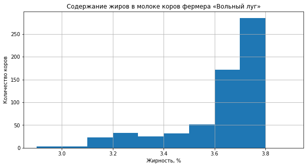

```python
quantitative_plot(main_data, 'жирность', 0.1)
plt.title('Содержание жиров в молоке коров фермера «Вольный луг»')
plt.xlabel('Жирность, %')
plt.show()
```

```python
print('Количество аномальных значений в столбце:',
      len(main_data[main_data['жирность'] < 3.4]))
main_data[main_data['жирность'] < 3.4].sort_values(by='жирность').head(10)
```

```
Количество аномальных значений в столбце: 86
```

|  | ид | удой | эке | сырой_протеин | спо | порода | тип_пастбища | порода_папы | жирность | белок | вкус_молока | возраст |
| --- | --- | --- | --- | --- | --- | --- | --- | --- | --- | --- | --- | --- |
| 561 | 562 | 5300 | 13.0 | 1785 | 0.860 | Вис Бик Айдиал | равнинное | Соверин | 2.99 | 3.077 | невкусно | менее 2 лет |
| 576 | 577 | 5376 | 11.7 | 1825 | 0.860 | Рефлешн Соверинг | равнинное | Соверин | 2.99 | 3.076 | невкусно | менее 2 лет |
| 568 | 569 | 5989 | 13.2 | 1721 | 0.860 | Вис Бик Айдиал | холмистое | Соверин | 2.99 | 3.076 | вкусно | менее 2 лет |
| 558 | 559 | 5346 | 12.4 | 1837 | 0.860 | Рефлешн Соверинг | холмистое | Соверин | 3.01 | 3.078 | невкусно | менее 2 лет |
| 554 | 555 | 5686 | 14.7 | 1712 | 0.860 | Рефлешн Соверинг | холмистое | Айдиал | 3.01 | 3.074 | вкусно | более 2 лет |
| 17 | 18 | 5777 | 12.4 | 1873 | 0.895 | Вис Бик Айдиал | холмистое | Айдиал | 3.03 | 3.080 | вкусно | более 2 лет |
| 602 | 603 | 5594 | 12.3 | 1742 | 0.880 | Вис Бик Айдиал | равнинное | Айдиал | 3.11 | 3.077 | вкусно | менее 2 лет |
| 34 | 35 | 5356 | 12.9 | 1734 | 0.885 | Вис Бик Айдиал | равнинное | Айдиал | 3.11 | 3.075 | невкусно | менее 2 лет |
| 36 | 37 | 6150 | 13.8 | 1702 | 0.930 | Вис Бик Айдиал | холмистое | Айдиал | 3.11 | 3.074 | вкусно | более 2 лет |
| 292 | 293 | 6071 | 14.9 | 2036 | 0.940 | Рефлешн Соверинг | холмистое | Соверин | 3.12 | 3.079 | вкусно | более 2 лет |

График выглядит необычно. Пик графика расположен в самом конце, в начале графика заметен большой хвост из малых значений. Странно, что отсутствуют значения свыше пиковых.

На диаграмме размаха 13.7% значений ниже 3.4% жирности отмечаются как аномальные, что довольно много. Эти значения нельзя назвать выбросами, т.к. они укладываются в норму показателей жирности молока, поэтому мы их оставим.

Разброс содержания жиров в молоке коров - от 2.99 до 3.75%.

Самые часто встречающиеся значения приходятся на промежуток 3.6-3.75%. В среднем жирность молока каждой коровы составляет 3.6%.

Также взглянем на данные коров, которых продает «ЭкоФерма».

```python
buy_data['жирность'].describe()
```

```
count    20.000000
mean      3.577500
std       0.126818
min       3.340000
25%       3.510000
50%       3.590000
75%       3.650000
max       3.770000
Name: жирность, dtype: float64
```

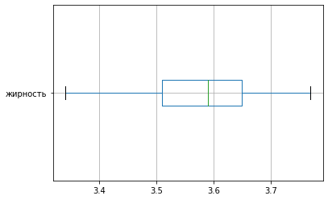

```python
buy_data.boxplot(column='жирность', vert=False);
```

```python
buy_data[buy_data['жирность'] < 3.5]
```

|  | порода | тип_пастбища | порода_папы | имя_папы | жирность | белок | возраст |
| --- | --- | --- | --- | --- | --- | --- | --- |
| 3 | Рефлешн Соверинг | холмистое | Айдиал | Буйный | 3.40 | 3.061 | более 2 лет |
| 9 | Рефлешн Соверинг | холмистое | Айдиал | Буйный | 3.40 | 3.079 | менее 2 лет |
| 13 | Вис Бик Айдиал | холмистое | Соверин | Барин | 3.42 | 3.075 | менее 2 лет |
| 15 | Рефлешн Соверинг | холмистое | Айдиал | Буйный | 3.40 | 3.065 | более 2 лет |
| 18 | Вис Бик Айдиал | равнинное | Соверин | Буйный | 3.34 | 3.069 | более 2 лет |

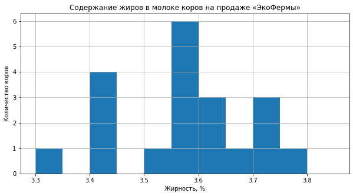

```python
quantitative_plot(buy_data, 'жирность', 0.05)
plt.title('Содержание жиров в молоке коров на продаже «ЭкоФермы»')
plt.xlabel('Жирность, %')
plt.show()
```

Разброс содержания жиров в молоке коров - от 3.34 до 3.77%.

В среднем жирность молока каждой коровы составляет 3.57%.

### Столбец `'белок'`

Изучим данные по содержанию белков в молоке коров фермера «Вольный луг».

```python
main_data['белок'].describe()
```

```
count    628.000000
mean       3.075670
std        0.002551
min        3.069000
25%        3.074000
50%        3.076000
75%        3.077000
max        3.085000
Name: белок, dtype: float64
```

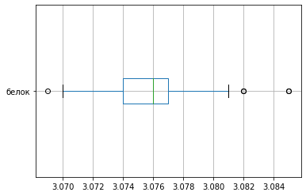

```python
main_data.boxplot(column='белок', vert=False);
```

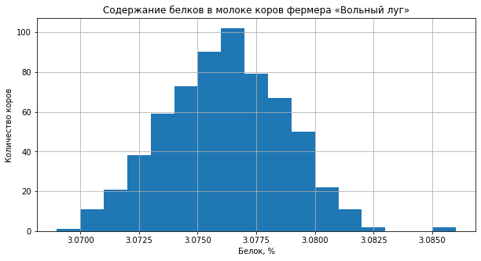

```python
quantitative_plot(main_data, 'белок', 0.001)
plt.title('Содержание белков в молоке коров фермера «Вольный луг»')
plt.xlabel('Белок, %')
plt.show()
```

Значения распределены нормально, в конце графика заметен выброс, равный 3.085%.

На диаграмме размаха значения ниже 3.07% и выше 3.081% отмечаются как выбросы, изучим их подробнее.

```python
print('Количество аномальных значений в столбце:',
      len(main_data[(main_data['белок'] > 3.081) | (main_data['белок'] < 3.07)]))
main_data[(main_data['белок'] > 3.081) | (main_data['белок'] < 3.07)]
```

```
Количество аномальных значений в столбце: 5
```

|  | ид | удой | эке | сырой_протеин | спо | порода | тип_пастбища | порода_папы | жирность | белок | вкус_молока | возраст |
| --- | --- | --- | --- | --- | --- | --- | --- | --- | --- | --- | --- | --- |
| 77 | 78 | 5871 | 14.7 | 1795 | 0.895 | Вис Бик Айдиал | равнинное | Айдиал | 3.61 | 3.082 | вкусно | более 2 лет |
| 240 | 241 | 5568 | 13.4 | 1733 | 0.880 | Вис Бик Айдиал | равнинное | Соверин | 3.63 | 3.069 | невкусно | менее 2 лет |
| 426 | 427 | 6701 | 15.7 | 2068 | 0.940 | Рефлешн Соверинг | холмистое | Айдиал | 3.72 | 3.082 | вкусно | более 2 лет |
| 471 | 472 | 5883 | 14.9 | 2159 | 0.890 | Вис Бик Айдиал | равнинное | Соверин | 3.62 | 3.085 | вкусно | более 2 лет |
| 517 | 518 | 5819 | 13.7 | 1968 | 0.840 | Вис Бик Айдиал | холмистое | Айдиал | 3.15 | 3.085 | вкусно | более 2 лет |

Этих аномальных данных немного, поэтому их можно удалить для улучшения качества моделей машинного обучения.

```python
main_data = main_data[(main_data['белок'] <= 3.081) & (main_data['белок'] >= 3.07)]
```

Разброс содержания белка в молоке коров - от 3.07 до 3.081%.

Самые часто встречающиеся значения приходятся на промежуток 3.075-3.077%. В среднем содержание белков в молоке каждой коровы составляет 3.075%.

Также взглянем на данные коров, которых продает «ЭкоФерма».

```python
buy_data['белок'].describe()
```

```
count    20.000000
mean      3.069500
std       0.010339
min       3.046000
25%       3.064000
50%       3.074000
75%       3.076000
max       3.081000
Name: белок, dtype: float64
```

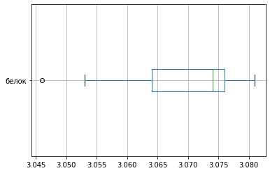

```python
buy_data.boxplot(column='белок', vert=False);
```

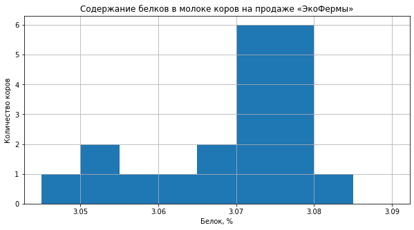

```python
quantitative_plot(buy_data, 'белок', 0.005)
plt.title('Содержание белков в молоке коров на продаже «ЭкоФермы»')
plt.xlabel('Белок, %')
plt.show()
```

Разброс содержания белка в молоке коров - от 3.046 до 3.081%.

### Столбец `'порода'`

Изучим данные по породе коров фермера «Вольный луг».

```
Количество значений:
Вис Бик Айдиал      368
Рефлешн Соверинг    255
```

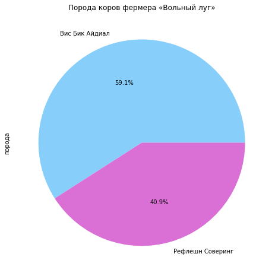

```python
print('Количество значений:')
print(main_data['порода'].value_counts().to_string(header=False))
categorical_plot(main_data, 'порода')
plt.title('Порода коров фермера «Вольный луг»')
plt.show()
```

Также взглянем на данные коров, которых продает «ЭкоФерма».

```
Количество значений:
Рефлешн Соверинг    11
Вис Бик Айдиал       9
```

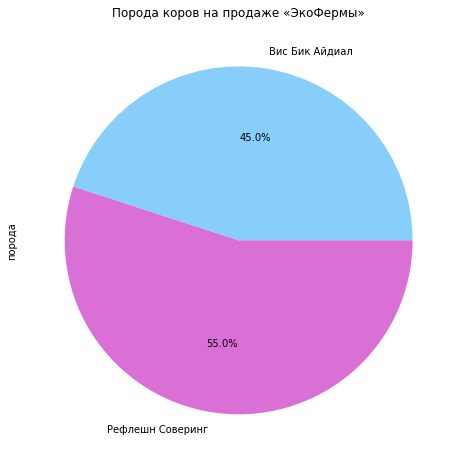

```python
print('Количество значений:')
print(buy_data['порода'].value_counts().to_string(header=False))
categorical_plot(buy_data, 'порода')
plt.title('Порода коров на продаже «ЭкоФермы»')
plt.show()
```

### Столбец `'тип_пастбища'`

Изучим данные по ландшафту лугов, на которых паслись коровы фермера «Вольный луг».

```
Количество значений:
холмистое    348
равнинное    275
```

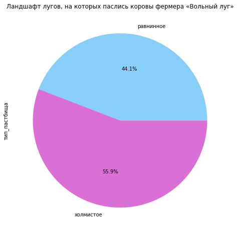

```python
print('Количество значений:')
print(main_data['тип_пастбища'].value_counts().to_string(header=False))
categorical_plot(main_data, 'тип_пастбища')
plt.title('Ландшафт лугов, на которых паслись коровы фермера «Вольный луг»')
plt.show()
```

Также взглянем на данные коров, которых продает «ЭкоФерма».

```
Количество значений:
равнинное    11
холмистое     9
```

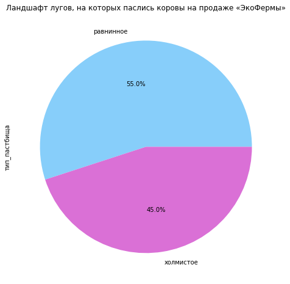

```python
print('Количество значений:')
print(buy_data['тип_пастбища'].value_counts().to_string(header=False))
categorical_plot(buy_data, 'тип_пастбища')
plt.title('Ландшафт лугов, на которых паслись коровы на продаже «ЭкоФермы»')
plt.show()
```

### Столбец `'порода_папы'`

Изучим данные по породе папы коров фермера «Вольный луг».

```
Количество значений:
Айдиал     314
Соверин    309
```

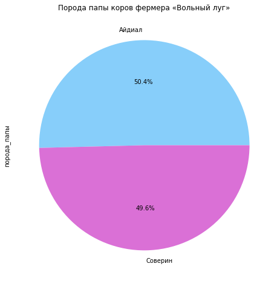

```python
print('Количество значений:')
print(main_data['порода_папы'].value_counts().to_string(header=False))
categorical_plot(main_data, 'порода_папы')
plt.title('Порода папы коров фермера «Вольный луг»')
plt.show()
```

Породы папы коров фермера представлены практически в равной степени. Коров с породой отца "Айдиал" больше всего на 1%, чем коров с породой отца "Соверин".

Также взглянем на данные коров, которых продает «ЭкоФерма».

```
Количество значений:
Соверин    12
Айдиал      8
```

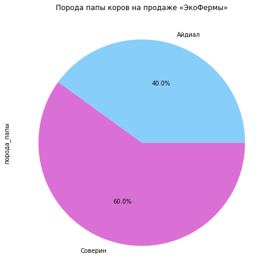

```python
print('Количество значений:')
print(buy_data['порода_папы'].value_counts().to_string(header=False))
categorical_plot(buy_data, 'порода_папы')
plt.title('Порода папы коров на продаже «ЭкоФермы»')
plt.show()
```

### Столбец `'возраст'`

Изучим данные по возрасту коров фермера «Вольный луг».

```
Количество значений:
более 2 лет    514
менее 2 лет    109
```

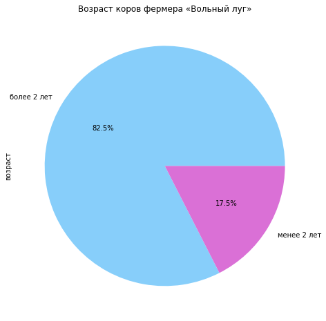

```python
print('Количество значений:')
print(main_data['возраст'].value_counts().to_string(header=False))
categorical_plot(main_data, 'возраст')
plt.title('Возраст коров фермера «Вольный луг»')
plt.show()
```

Подавляющее число коров фермера имеют возраст более 2 лет - 82.5%. Молодых коров до 2 лет меньше почти в 5 раз - всего 17.5%, разница составляет 65%.

Также взглянем на данные коров, которых продает «ЭкоФерма».

```
Количество значений:
более 2 лет    15
менее 2 лет     5
```

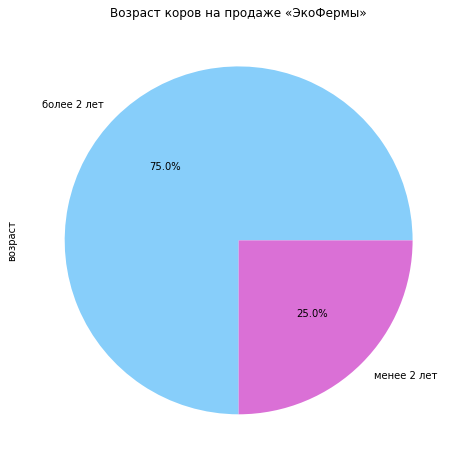

```python
print('Количество значений:')
print(buy_data['возраст'].value_counts().to_string(header=False))
categorical_plot(buy_data, 'возраст')
plt.title('Возраст коров на продаже «ЭкоФермы»')
plt.show()
```

### Столбец `'имя_папы'`

Изучим данные по имени папы коров фермера «Вольный луг».

```
Количество значений:
Барин       240
Буйный      215
Соловчик    110
Геркулес     64
```

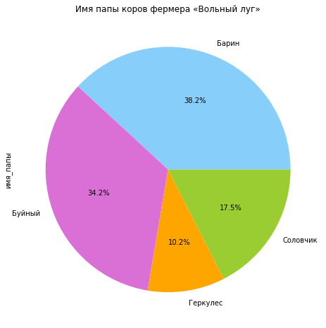

```python
print('Количество значений:')
print(dad_data['имя_папы'].value_counts().to_string(header=False))
categorical_plot(dad_data, 'имя_папы')
plt.title('Имя папы коров фермера «Вольный луг»')
plt.show()
```

Большинство коров фермера произошли от быков по имени Барин (38.2%) и Буйный (34.2%). Коровы от других быков представлены в меньшей степени - от Соловчика 17.5%, от Геркулеса 10.2%.

Также взглянем на данные коров, которых продает «ЭкоФерма».

```
Количество значений:
Буйный      8
Геркулес    6
Барин       4
Соловчик    2
```

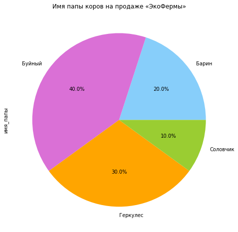

```python
print('Количество значений:')
print(buy_data['имя_папы'].value_counts().to_string(header=False))
categorical_plot(buy_data, 'имя_папы')
plt.title('Имя папы коров на продаже «ЭкоФермы»')
plt.show()
```

### Вывод

```python
for data_name in all_data:
    data = eval(data_name)
    print(f'Длина датафрейма "{data_name}": {data.shape[0]}')
```

```
Длина датафрейма "main_data": 623
Длина датафрейма "dad_data": 629
Длина датафрейма "buy_data": 20
```

Из датафрейма `main_data` было удалено 6 аномальных значений: 1 из столбца `'удой'`, 5 из столбца `'белок'`.

**Информация о коровах фермера «Вольный луг»**

Удой коров фермера варьируется от 5204 до 7222 кг в год. В среднем каждая корова даёт 6126 кг молока в год.

Разброс показателя питательности корма коров - от 10.9 до 16.8. В среднем энергетическая кормовая единица каждой коровы составляет 14.5.

Содержание сырого протеина в корме варьируется от 1660 до 2349 г. В среднем каждая корова получает 1923 г сырого протеина.

Отношение сахара к протеину в корме коровы имеет значения от 0.84 до 0.96. Большинство коров имеют показатель СПО в районе 0.93-0.94. В среднем отношение сахара к протеину в корме составляет 0.91.

58.9% коров фермера по его субъективной оценке имеют вкусное молоко, у 41.1% коров молоко невкусное, что на 17.8% меньше первых.

Разброс содержания жиров в молоке коров - от 2.99 до 3.75%. В среднем жирность молока каждой коровы составляет 3.6%.

Разброс содержания белка в молоке коров - от 3.07 до 3.081%. В среднем содержание белков в молоке каждой коровы составляет 3.075%.

Подавляющее число коров фермера имеют возраст более 2 лет - 82.5%. Молодых коров до 2 лет меньше почти в 5 раз - всего 17.5%, разница составляет 65%.

Большинство коров фермера произошли от быков по имени Барин (38.2%) и Буйный (34.2%). Коровы от других быков представлены в меньшей степени - от Соловчика 17.5%, от Геркулеса 10.2%.

**Информация о коровах на продаже «ЭкоФермы»**

Содержание жиров в молоке коров варьируется от 3.34 до 3.77%. В среднем жирность молока каждой коровы составляет 3.57%.

Вернуться к содержанию

## Корреляционный анализ

### Расчет коэффициентов корреляции

Изучим взаимосвязи между признаками датафрейма. Для этого построим матрицы корреляции по всем признакам.

Для удобства изучения построим три матрицы:

- матрица корреляции количественных признаков с категориальными,
- матрица корелляции категориальных признаков друг с другом,
- матрица корелляции количественных признаков друг с другом.

```python
display(HTML('<h3>Матрица корреляции количественных признаков с категориальными</h3>'))
main_data[main_data.columns[1:]]\
    .phik_matrix(interval_cols=int_col(main_data))\
    .drop(cat_col(main_data), axis=1)\
    .drop(int_col(main_data)[1:], axis=0)\
    .style.background_gradient('cividis')
```

Матрица корреляции количественных признаков с категориальными

|  | удой | эке | сырой_протеин | спо | жирность | белок |
| --- | --- | --- | --- | --- | --- | --- |
| порода | 0.162958 | 0.115077 | 0.085472 | 0.052108 | 0.222665 | 0.375280 |
| тип_пастбища | 0.274778 | 0.103464 | 0.084767 | 0.145166 | 0.000000 | 0.149085 |
| порода_папы | 0.518814 | 0.173375 | 0.000000 | 0.427383 | 0.000000 | 0.078668 |
| вкус_молока | 0.173285 | 0.273181 | 0.173276 | 0.572829 | 0.201406 | 0.107450 |
| возраст | 0.998067 | 0.772487 | 0.348442 | 0.748693 | 0.682940 | 0.000000 |

```python
display(HTML('<h3>Матрица корреляции категориальных признаков друг с другом</h3>'))
main_data[main_data.columns[1:]]\
    .phik_matrix(interval_cols=int_col(main_data))\
    .drop(int_col(main_data)[1:], axis=1)\
    .drop(int_col(main_data)[1:], axis=0)\
    .style.background_gradient('cividis')
```

Матрица корреляции категориальных признаков друг с другом

|  | порода | тип_пастбища | порода_папы | вкус_молока | возраст |
| --- | --- | --- | --- | --- | --- |
| порода | 1.000000 | 0.206840 | 0.093854 | 0.000000 | 0.053406 |
| тип_пастбища | 0.206840 | 1.000000 | 0.000000 | 0.268762 | 0.123505 |
| порода_папы | 0.093854 | 0.000000 | 1.000000 | 0.000000 | 0.351328 |
| вкус_молока | 0.000000 | 0.268762 | 0.000000 | 1.000000 | 0.156310 |
| возраст | 0.053406 | 0.123505 | 0.351328 | 0.156310 | 1.000000 |

Матрица корреляции количественных признаков друг с другом

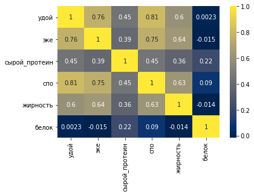

```python
display(HTML('<h3>Матрица корреляции количественных признаков друг с другом</h3>'))
sns.heatmap(main_data[main_data.columns[1:]].corr(), annot=True, cmap ='cividis');
```

Составим список по всем признакам, которые имеют друг с другом связь в порядке убывания.

```python
# Вычисляем матрицу корреляции для количественных данных
quantitative_corr = main_data[main_data.columns[1:]].corr()

# Вычисляем матрицу корреляции для категориальных данных
categorical_corr = main_data[main_data.columns[1:]]\
    .phik_matrix(interval_cols=int_col(main_data))\
    .drop(int_col(main_data)[1:], axis=0)

# Создаем словарь для сохранения результатов
results = {}

# Перебираем все столбцы
for column in main_data.columns[1:]:

    # Создаем словарь для этого столбца
    results[column] = {'Сильная': [], 'Заметная': [], 'Умеренная': [], 'Слабая': []}

    # Проверяем, является ли столбец количественным или категориальным
    if column in quantitative_corr.columns:
        # Объединяем корреляции из quantitative_corr и categorical_corr
        correlations = pd.concat([quantitative_corr[column], categorical_corr[column]])
    else:
        # Получаем корреляции по строке для категориальных столбцов
        correlations = categorical_corr.loc[column]

    # Сортируем корреляции по убыванию
    correlations = correlations.sort_values(ascending=False)

    # Удаляем корреляцию столбца с самим собой
    if column in correlations:
        correlations = correlations.drop(column)

    # Добавляем корреляции в словарь
    for column2, corr_result in correlations.items():
        if corr_result >= 0.7:
            results[column]['Сильная'].append(f'{column2} ({round(corr_result, 2)})')
        elif corr_result >= 0.5:
            results[column]['Заметная'].append(f'{column2} ({round(corr_result, 2)})')
        elif corr_result >= 0.3:
            results[column]['Умеренная'].append(f'{column2} ({round(corr_result, 2)})')
        elif corr_result >= 0.1:
            results[column]['Слабая'].append(f'{column2} ({round(corr_result, 2)})')

# Выводим результаты
for column, correlations in results.items():
    display(HTML(f'<br><b>{column}:</b>'))
    for category, corr_list in correlations.items():
        # Проверяем, пуст ли список
        if len(corr_list) > 0:
            print(f'{category}: {", ".join(corr_list)}')
```

**удой:**

```
Сильная: возраст (1.0), спо (0.81), эке (0.76)
Заметная: жирность (0.6), порода_папы (0.52)
Умеренная: сырой_протеин (0.45)
Слабая: тип_пастбища (0.27), вкус_молока (0.17), порода (0.16)
```

**эке:**

```
Сильная: возраст (0.77), удой (0.76), спо (0.75)
Заметная: жирность (0.64)
Умеренная: сырой_протеин (0.39)
Слабая: вкус_молока (0.27), порода_папы (0.17), порода (0.12), тип_пастбища (0.1)
```

**сырой_протеин:**

```
Умеренная: спо (0.45), удой (0.45), эке (0.39), жирность (0.36), возраст (0.35)
Слабая: белок (0.22), вкус_молока (0.17)
```

**спо:**

```
Сильная: удой (0.81), эке (0.75), возраст (0.75)
Заметная: жирность (0.63), вкус_молока (0.57)
Умеренная: сырой_протеин (0.45), порода_папы (0.43)
Слабая: тип_пастбища (0.15)
```

**порода:**

```
Умеренная: белок (0.38)
Слабая: жирность (0.22), тип_пастбища (0.21), удой (0.16), эке (0.12)
```

**тип_пастбища:**

```
Слабая: удой (0.27), вкус_молока (0.27), порода (0.21), белок (0.15), спо (0.15), возраст (0.12), эке (0.1)
```

**порода_папы:**

```
Заметная: удой (0.52)
Умеренная: спо (0.43), возраст (0.35)
Слабая: эке (0.17)
```

**жирность:**

```
Заметная: возраст (0.68), эке (0.64), спо (0.63), удой (0.6)
Умеренная: сырой_протеин (0.36)
Слабая: порода (0.22), вкус_молока (0.2)
```

**белок:**

```
Умеренная: порода (0.38)
Слабая: сырой_протеин (0.22), тип_пастбища (0.15), вкус_молока (0.11)
```

**вкус_молока:**

```
Заметная: спо (0.57)
Слабая: эке (0.27), тип_пастбища (0.27), жирность (0.2), удой (0.17), сырой_протеин (0.17), возраст (0.16), белок (0.11)
```

**возраст:**

```
Сильная: удой (1.0), эке (0.77), спо (0.75)
Заметная: жирность (0.68)
Умеренная: порода_папы (0.35), сырой_протеин (0.35)
Слабая: вкус_молока (0.16), тип_пастбища (0.12)
```

В матрице сразу можно заметить очень высокую корреляцию между удоем и возрастом, практически равную 1. Между признаками имеется сильная линейная взаимосвязь, но также возраст очень сильно коррелирует с СПО и ЭКЕ, как и удой, поэтому они являются мультиколлинеарными.

Между некоторыми признаками корреляция является случайной. Это относится к признакам, которые относятся к одной группе (например, все признаки, характеризующие молоко - удой, белок, жирность, вкус молока).